# Module 12. Study planning, reporting and reproducibility

Slides

# Design starts from the estimand

## Different questions need different schedules

| Question | Schedule implication |
| --- | --- |
| Difference in mean change at month 12 | Precise baseline and final visits; intermediate visits help under dropout |
| Difference in linear rates of change | Spread visits widely; the ends are most informative |
| When does the effect appear? | Front-load visits where change is expected |
| How much do individuals differ in change? | Several visits per person over a long period |
| Is the effect sustained? | Long follow-up beyond the plateau |

## WALK front-loads its visits because change is early

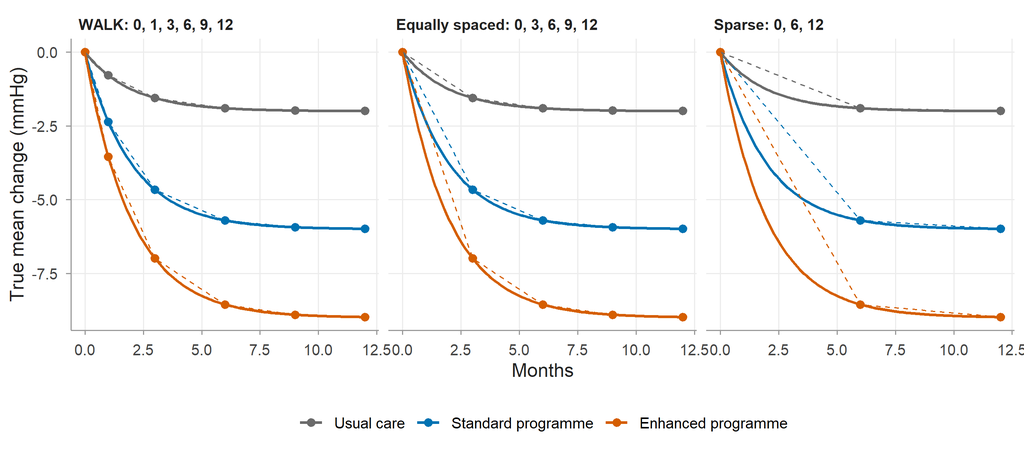

39% of the change by month 1, 78% by month 3 (simulated truth).

# How design choices affect precision

## The variance of a slope difference has two parts

$$\text{Var}(\hat\beta_3) = \frac{2}{n}\left(\tau_1^2 + \frac{\sigma^2}{S_{tt}}\right),\qquad S_{tt} = \sum_j (t_j - \bar t)^2$$

- $\tau_1^2$: true differences in slopes between people; only more participants reduce it
- $\sigma^2/S_{tt}$: noise in each person’s fitted slope; spreading visits reduces it
- $\tau_0^2$ does not appear: each participant is their own control

## More visits help with diminishing returns; placement matters too

| Schedule | S_tt | SE, 50 per arm | n per arm, 90% power |
| --- | --- | --- | --- |
| 0, 12 | 72.0 | 0.162 | 56 |
| 0, 6, 12 | 72.0 | 0.162 | 56 |
| 0, 3, 6, 9, 12 | 90.0 | 0.150 | 48 |
| 0, 1, 3, 6, 9, 12 (WALK) | 110.8 | 0.139 | 41 |
| 0, 0.5, …, 12 (25 visits) | 325.0 | 0.104 | 23 |
| 0, 1, 2, 10, 11, 12 | 154.0 | 0.126 | 34 |

$\tau_1 = 0.4$ mmHg/month, $\sigma = 6$ mmHg, $\Delta = -0.5$ mmHg/month.

## The formula agrees with 500 simulated trials

| Quantity | Value |
| --- | --- |
| Formula SE | 0.1497 |
| Mean model-based SE | 0.1490 |
| Empirical SD of estimates | 0.1586 |
| Monte Carlo SE of the empirical SD | 0.0050 |
| Mean estimate (truth -0.5) | -0.4943 |

## Correlation helps within-person comparisons

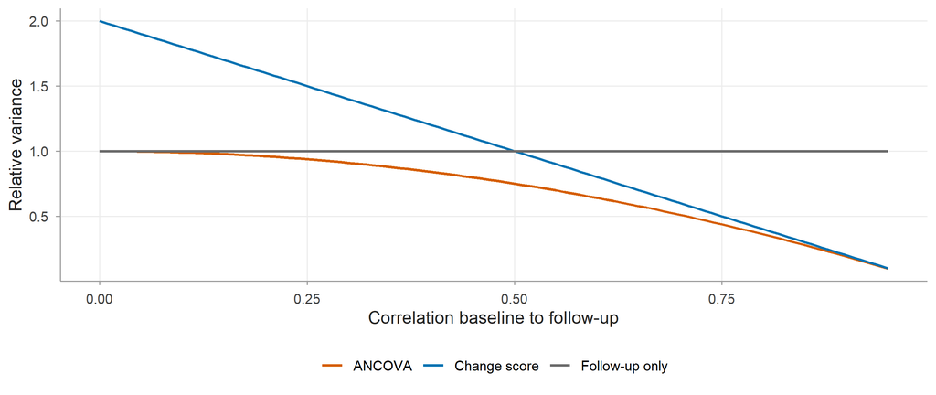

WALK: correlation 0.69, so ANCOVA needs about 53% of the sample size of a follow-up-only analysis.

## Dropout removes information, but not all of it

Participant seen at the first $k$ visits contributes $w_k = 1/(\tau_1^2 + \sigma^2/S_{tt,k})$:

$$\text{Var}(\hat\beta_3) \approx \frac{2}{n\sum_k \pi_k w_k}$$

With 50 per arm, approximate power 0.92 (no dropout), 0.81 (dropout 0.1 per visit) and 0.67 (0.2 per visit).

## Try it

Workbook 12, **Exercises G1 and G2**: schedules, $S_{tt}$ and the sample-size formula.

# Simulation-based power

## Power by simulation: simulate, analyse, count rejections

$$\widehat{\text{power}} = \frac{1}{n_{\text{sim}}}\sum_s \mathbb{1}(p_s < \alpha),
\qquad \text{MCSE} = \sqrt{\widehat{\text{power}}(1-\widehat{\text{power}})/n_{\text{sim}}}$$

```r
power_two_arm(n_sims = 200, seed = 1, n_per_arm = 50, dropout = 0.1)
```

[output not shown]

MCSE ≤ 0.01 at power 0.8 needs $0.8 \times 0.2 / 0.01^2 = 1600$ simulated trials.

## Power rises with n and falls with dropout

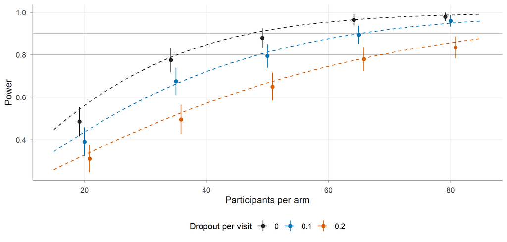

## A power estimate without its Monte Carlo SE cannot be judged

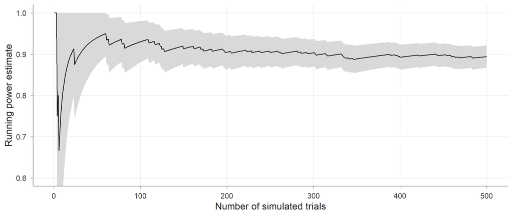

After 500 trials: 0.894 (MCSE 0.014).

## Try it

Workbook 12, **Exercises G3 and G4**: power and type I error by simulation.

# Writing the analysis plan

## A SAP fixes the analysis before the data can influence it

- Structure from Gamble et al. (2017); estimands from ICH E9(R1) (International Council for Harmonisation of Technical Requirements for Pharmaceuticals for Human Use (ICH) 2019)
- Longitudinal additions: schedule and visit windows; time scale; full model; responses to diagnostic and fitting problems; missing-data assumption and sensitivity analyses
- Template: `final-project/sap_template.md`
- Filled example: `admin/templates/walk_sap_example.md`

## The WALK primary estimand, written out

| Attribute | WALK |
| --- | --- |
| Treatment | Assignment to EP (or SP) vs UC |
| Population | Adults with raised SBP meeting eligibility criteria |
| Variable | Change in SBP, baseline to month 12 |
| Intercurrent events | Stopping the programme: treatment policy. New antihypertensive: treatment policy (hypothetical as supplementary) |
| Summary | Difference in mean change, mmHg |

## Try it

Workbook 12, **Exercise G5**: an estimand table for CLEAR.

# Reporting

## Report enough to reconstruct the model and judge it

- Design and data: schedule, numbers of participants **and** observations, missingness by arm and visit
- Model: mean model, time, random effects/covariance, estimation, df method, software versions
- Estimand and how it is computed; MAR assumption and sensitivity analyses
- Results: EP − UC at month 12 -9.0 (-11.8 to -6.1) mmHg; SP − UC -5.4 (-8.2 to -2.6) mmHg

## Try it

Workbook 12, **Independent exercise I3**: write methods and results for the DIARY model.

# Reproducibility

## A project that anyone can run from top to bottom

```
LDA_course/
├── LDA_course.Rproj   opens with the project root as working directory
├── R/                 shared functions (setup.R)
├── data-raw/ data/    data are created by code, never edited by hand
├── scripts/           numbered: 00_make_data.R ... 12_planning.R
└── outputs/           figures/, tables/, models/ (written by scripts)
```

- `here::here("data", "walk_long.csv")`: paths from the project root; never `setwd()`
- Numbered scripts, one-way data flow, outputs saved by code

## Record and restore the package versions

- `sessionInfo()` records what was used (saved in `outputs/m12_session_info.txt`)
- **renv** (Ushey and Wickham 2026) restores it:
  - `renv::init()`: project library and `renv.lock` (once)
  - `renv::snapshot()`: update the lockfile after package changes
  - `renv::restore()`: install the recorded versions elsewhere
- Git: commit small changes with messages, `.gitignore` personal data, tag the reported version

## Try it

Workbook 12, **Exercise G6** and the independent exercises.

## Summary

- Choose the schedule from the estimand; front-load when change is early
- $\text{Var}(\hat\beta_3) = 2(\tau_1^2 + \sigma^2/S_{tt})/n$: participants beat visits once $\tau_1^2$ dominates
- Simulate realistic designs, and report Monte Carlo SEs
- Write the SAP first: estimand, model, responses to problems, missing data
- Report against a checklist; make the project reproducible with `here`, numbered scripts, `sessionInfo()`, renv and Git

Arnold, Benjamin F., Daniel R. Hogan, John M. Colford, and Alan E. Hubbard. 2011. ‘Simulation Methods to Estimate Design Power: An Overview for Applied Research’. *BMC Medical Research Methodology* 11: 94. https://doi.org/10.1186/1471-2288-11-94.

Gamble, Carrol, Ashma Krishan, Deborah Stocken, et al. 2017. ‘Guidelines for the Content of Statistical Analysis Plans in Clinical Trials’. *JAMA* 318 (23): 2337–43. https://doi.org/10.1001/jama.2017.18556.

International Council for Harmonisation of Technical Requirements for Pharmaceuticals for Human Use (ICH). 2019. *ICH Harmonised Guideline E9(R1): Addendum on Estimands and Sensitivity Analysis in Clinical Trials to the Guideline on Statistical Principles for Clinical Trials*. Step 4 guideline. ICH. https://www.ema.europa.eu/documents/scientific-guideline/ich-e9-r1-addendum-estimands-sensitivity-analysis-clinical-trials-guideline-statistical-principles_en.pdf.

Morris, Tim P., Ian R. White, and Michael J. Crowther. 2019. ‘Using Simulation Studies to Evaluate Statistical Methods’. *Statistics in Medicine* 38 (11): 2074–102. https://doi.org/10.1002/sim.8086.

Senn, Stephen. 2006. ‘Change from Baseline and Analysis of Covariance Revisited’. *Statistics in Medicine* 25 (24): 4334–44. https://doi.org/10.1002/sim.2682.

Ushey, Kevin, and Hadley Wickham. 2026. *renv: Project Environments*. https://CRAN.R-project.org/package=renv.

Vickers, Andrew J., and Douglas G. Altman. 2001. ‘Analysing Controlled Trials with Baseline and Follow up Measurements’. *BMJ* 323 (7321): 1123–24. https://doi.org/10.1136/bmj.323.7321.1123.